# Analysis of the Velopass data

```r
knitr::opts_chunk$set(cache=FALSE)
knitr::opts_chunk$set(echo=TRUE)
knitr::opts_chunk$set(fig.width=14)
knitr::opts_chunk$set(fig.height=14)
prjpath <- "~/work/citiviz/bikeSharing/bikestats/"
datapath <- paste(prjpath, "data/velopass_data/", sep="")
analpath <- paste(prjpath, "analyses/", sep="")
rcodepath <- paste(analpath, "Rcode/", sep="")
setwd(analpath)
library(lattice)
```

# 1 Introduction

We analyze the data from velopass.

# 2 Data collation

There are 6 pages of data for the year 2010. We will create a single data-frame from them.

```r
dd <- paste(datapath, "transactions_campus_2010/", sep="")
vlp2010.1 <- read.csv(paste(dd, "transactions_page1_2010.csv", sep=""),
                                            sep=";",    stringsAsFactors=FALSE)
vlp2010.2 <- read.csv(paste(dd, "transactions_page2_2010.csv", sep=""),
                                            sep=";",    stringsAsFactors=FALSE)
vlp2010.3 <- read.csv(paste(dd, "transactions_page3_2010.csv", sep=""),
                                            sep=";",    stringsAsFactors=FALSE)
vlp2010.4 <- read.csv(paste(dd, "transactions_page4_2010.csv", sep=""),
                                            sep=";",    stringsAsFactors=FALSE)
vlp2010.5 <- read.csv(paste(dd, "transactions_page5_2010.csv", sep=""),
                                            sep=";",    stringsAsFactors=FALSE)
vlp2010.6 <- read.csv(paste(dd, "transactions_page6_2010.csv", sep=""),
                                            sep=";",    stringsAsFactors=FALSE)
```

There is a column “X” in some of the data sets, which we will not include in our unified data frame.

```r
vlp2010.list <- list(vlp2010.1, vlp2010.2, vlp2010.3, vlp2010.4, vlp2010.5, vlp2010.6)
vlp2010 <- do.call(rbind, lapply(vlp2010.list, function(vlpy) vlpy[, -6]))
```

We also need to use our naming scheme for the variables.

```r
source(paste(rcodepath, "datamanip.R", sep=""))
nms.indata <- names(vlp2010)
names(vlp2010) <- namingScheme(nms.indata,
                                                             var.user_id="user_id",
                                                             var.start_statn="from_station",
                                                             var.end_statn="to_station",
                                                             var.start_time="from_timestamp",
                                                             var.end_time="to_timestamp",
                                                             var.trip_id=NA)
```

The dates in *vlp2010* are if the form “MON dd - h:m:s”. To use our libraries we will have translate the Italian month names in MON to English, and prepend the dates by year.

Some of the code below uses gender, which is not available in the data,

Lets save the combined data-frame to a file,

The data in *vlp2010* is for several months. Let us begin our analysis by looking at a single month’s worth of data,

# 3 Analyses

The following is a paste from *userPerspective.Rmd* that was written while analyzing hubway data.

# 4 Adding features to the data

Biker behavior in the morning can be different from that in the afternoon. We will divide each day into periods,

# 5 Transactions

We have written a function to convert trips to transactions (see *datamanip.Rmd*), that we use to convert the trips to transactions in the hubway sample.

The columns in the transactions are,

```
## [1] "user_id" "gender"  "period"  "time"    "statn"   "drxn"
```

The column *statn* should provide the location of the bike-station, either directly as (long, lat) or as a label along with a dictionary that can be queried with that label. From now on we will have two forms for the data, as trips, and as transactions.

We can take a peek at the transactions in our sample week,

```
##         user_id gender period                time        statn drxn
## 21308 888200178   Both   morn 2010-06-01 09:04:33   0134 Sorge  out
## 21309      7537   Both   morn 2010-06-01 09:13:28            -  out
## 21310    195624   Both   morn 2010-06-01 09:17:18  0132 Rivier  out
## 21311 888201178   Both   morn 2010-06-01 10:18:25 0135 Dorigny  out
## 21312    167177   Both   morn 2010-06-01 10:30:57            -  out
## 21313      2079   Both   morn 2010-06-01 10:36:09   0102 Ouchy  out
```

Transalting transactions to trips is harder, and will be implemented later.

# 6 Statistics for a single user

How often does a user use bikes? At what time of day? Which stations are most frequented by a user? What is the duration of a user’s trips?

Lets explore usage traces of some users,

What about the intermittency of use by an individual user?

# 7 User features

In order to study the users, we extract features from their usage data. The features we will discuss are as follows, 1. Frequency of use 2. Duration of trips 3. Intermittency of use 4. The diversity of start stations 5. The diversity of end stations 6. The diversity of (start, end) station pairs.

Lets explore user frequencies,

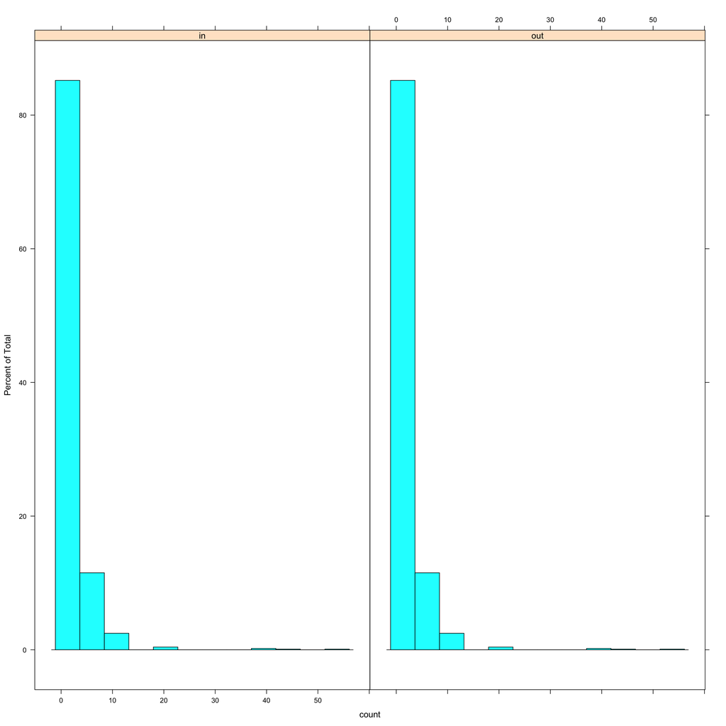

## 7.1 Frequency of use by time of day

We have the variable *period* that we can use to study the period of the day when the bikes are used.

```
## [1] "user_id" "gender"  "period"  "time"    "statn"   "drxn"
```

[figure not shown]

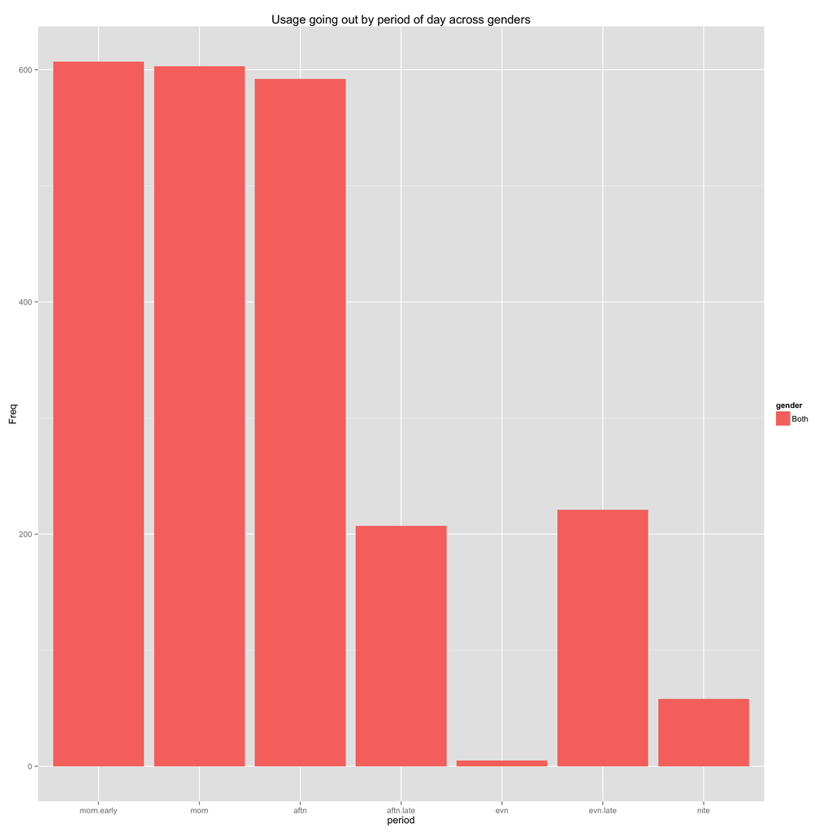

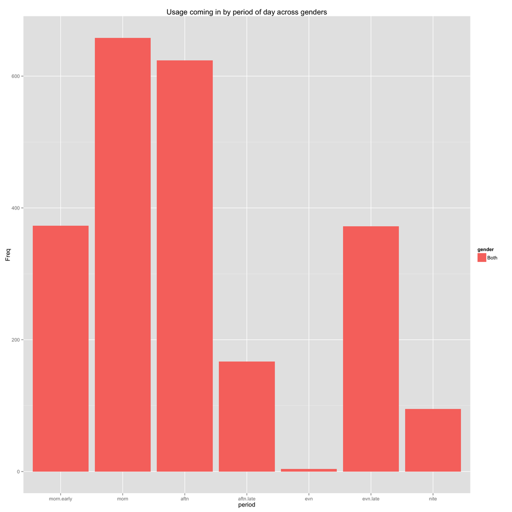

## 7.2 Intermittency of use

## 7.3 Duration of trips

Duration of trips can be easily extracted from *trips*

And now we can use the function to obtain the durations of user’s trips,

## 7.4 Diversity of stations

There aere three diversity values we can define for the stations that a user frequents, start, end and the start-to-end stations of each trip.

### 7.4.1 Gathered user features

Ok, now lets put all that we have together,

We can now cluster the users,

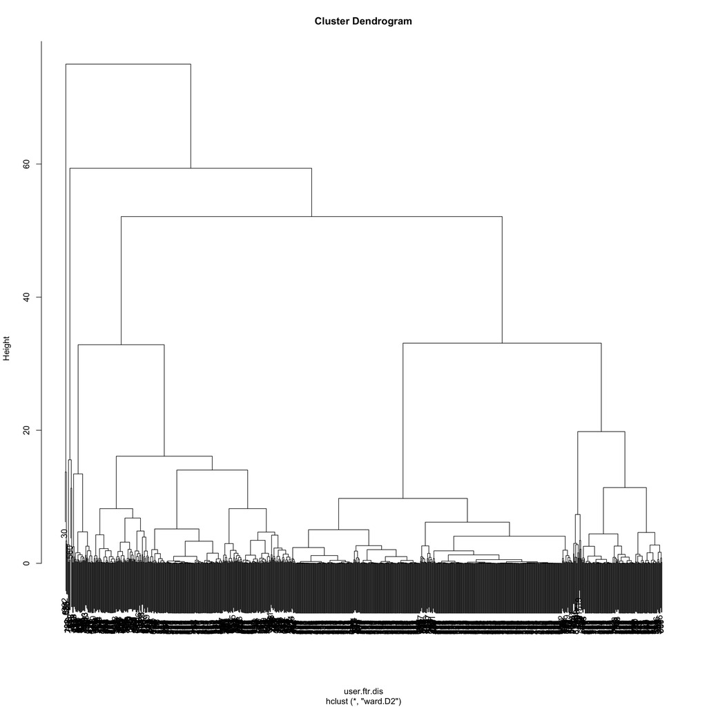

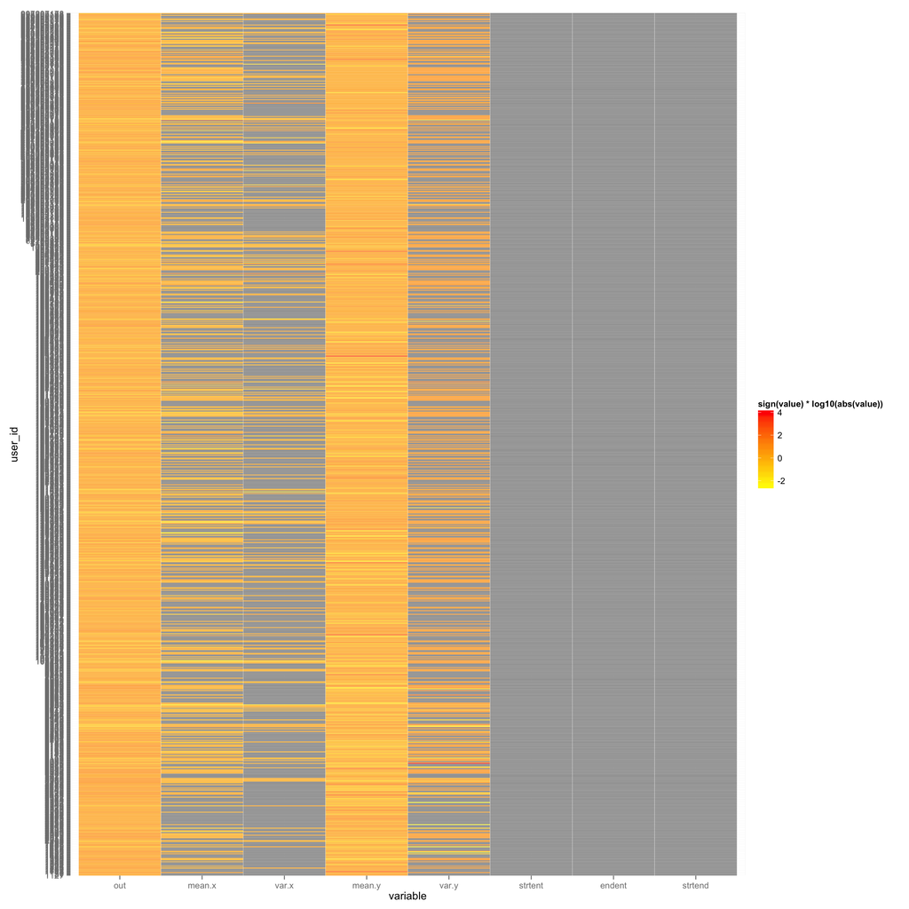